# Projet RDSM

2024-2025

**Nom : BOUHENDJEUR**  
**Prénom : Linda**

**Nom : DOSSOU**  
**Prénom : Félicia**

```r
library(tidyr)
library(dplyr)
library(ggplot2)
library(lubridate)
library(MASS)
library(FactoMineR)
library(corrplot)
library(factoextra)
library(plotly)
library(naniar)
library(Factoshiny)
library(corrplot)
library(knitr)
library(kableExtra)
library(gridExtra)
library(broom)
library(tibble)
```

Les données ont été nettoyées en supprimant les valeurs manquantes et la variable inutilisable PM2.5, réduites à 7852 observations sur 27 variables, enrichies par des colonnes jour, heure, et un identifiant temporel personnalisé, puis réorganisées en supprimant les variables redondantes.

```r
load("ATMO-RDSM.rda")

head(df)
# View(df)

glimpse(df)
str(df)
dim(df)

summary(df)
sapply(df, class)

print(miss_var_summary(df, n=35))
df$PM2.5<-NULL
print(miss_var_summary(df),n=35)
df<-df%>%na.omit()
print(miss_var_summary(df),n=35)
dim(df)

df<-df %>% mutate(jour=wday(date_debut,label=TRUE,abbr=FALSE))
df<-df%>%mutate(heure=hour(date_debut))

rownames.df<-paste(df$date_debut%>%day(),
df$date_debut%>%month(),
df$date_debut%>%hour(),sep=".")

df <- df %>% mutate(date = as.Date(date_debut))

df <- df %>% select(-c(date_debut, date_debut_standard))

df <- df %>% select(jour, date, heure, everything())

head(df)
```

## 2.1 Analyse globale des corrélations

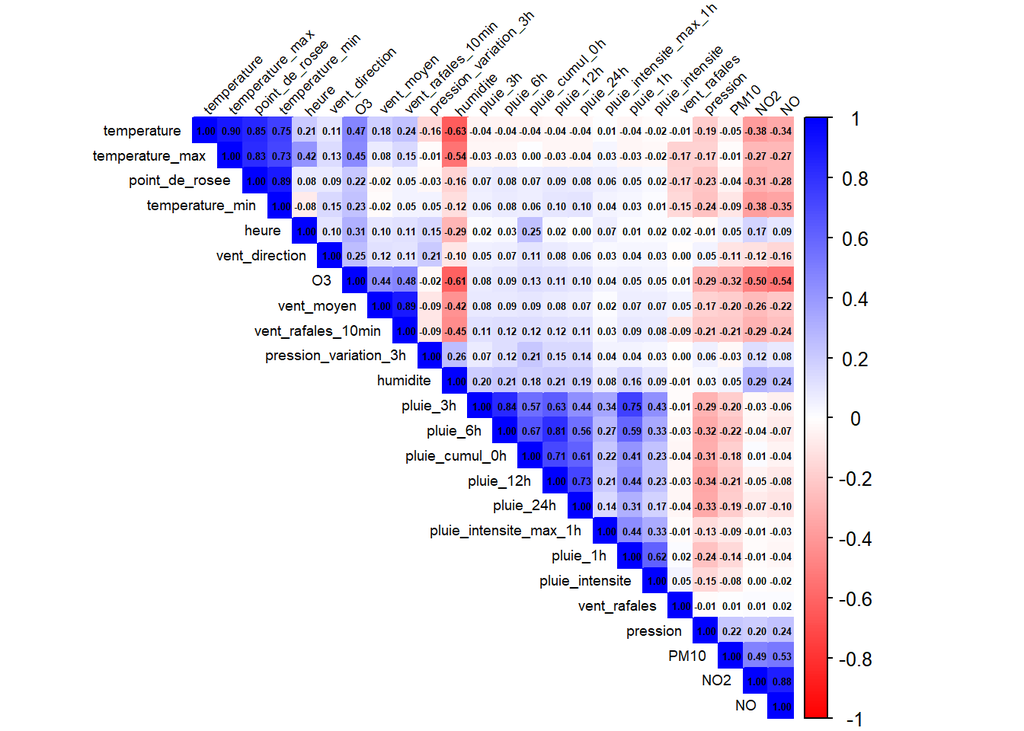

```r
df_numeric <- df %>% select_if(is.numeric)

cor_matrix <- cor(df_numeric, use = "complete.obs")

corrplot(cor_matrix, method = "color", type = "upper", order = "hclust",
         addCoef.col = "black", number.cex = 0.4, tl.col = "black", tl.srt = 45,
         col = colorRampPalette(c("red", "white", "blue"))(200),
         tl.cex = 0.6)
```

Des corrélations intéressantes apparaissent entre certaines variables. On observe une corrélation négative modérée entre l’humidité et les varaibles de température, O3 et vent. Les variables liées aux précipitations (pluie_0h à 24h) présentent des corrélations positives entre elles, reflétant une cohérence dans les niveaux de pluie mesurés à différents moments de la journée. Les variables liées à la température et au point de rosée montrent des corrélations positives. Enfin, les polluants (PM10, NO2, NO) sont corrélés positivement entre eux, tandis que NO2 et NO affichent une corrélation négative modérée avec la température et le point de rosée, l’O3.

## 2.2 Liens entre Ozone et autres variables

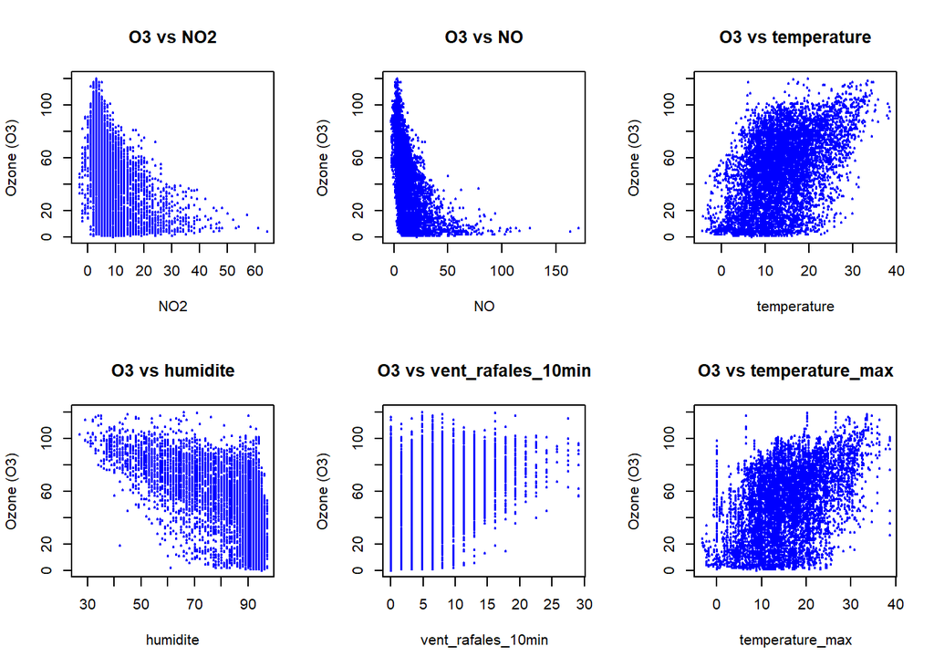

```r
correlations <- cor(df_numeric, use = "complete.obs")["O3", ]
variables_liees <- names(correlations[abs(correlations) > 0.45 & names(correlations) != "O3"])

par(mfrow = c(2, 3))

for (var in variables_liees) {
  plot(df[[var]], df$O3,
       xlab = var, ylab = "Ozone (O3)",
       main = paste("O3 vs", var),
       col = "blue", pch = 19, cex = 0.3)
}
```

De facon générale, les concentrations plus élevées des polluants NO2 et NO sont associées à des niveaux plus faibles d’ozone. En revanche, l’ozone semble augmenter avec la température. Les températures maximales suivent une tendance similaire à la température, renforçant l’idée que des conditions chaudes favorisent la production d’ozone. Cependant, la dispersion des points indique de grands écarts entre les températures. Les graphiques montrent également une relation négative avec l’humidité, indiquant que des conditions plus sèches favorisent des niveaux d’ozone plus élevés. Enfin, La concentration d’ozone semble légèrement augmenter avec la vitesse des rafales de vent sur 10 minutes, bien que la dispersion reste importante.

## 2.3 Distribution de l’ozone par heure et jour

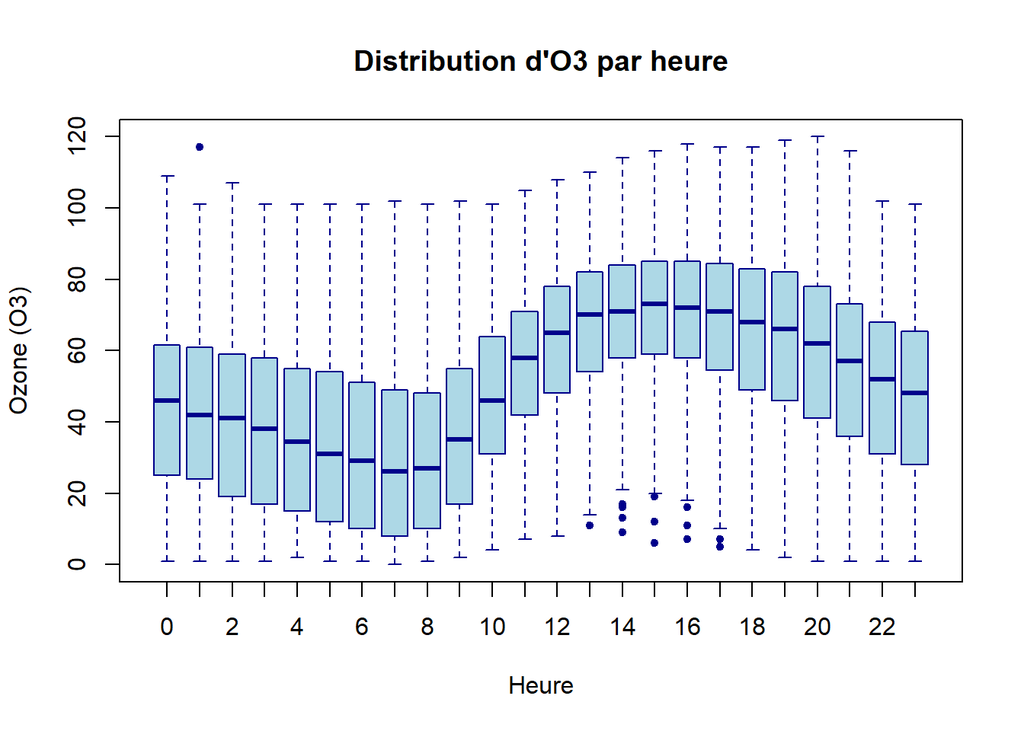

```r
boxplot(O3 ~ heure, data = df,
        xlab = "Heure", ylab = "Ozone (O3)",
        main = "Distribution d'O3 par heure",
        col = "lightblue", border = "darkblue",
        outline = TRUE,
        pch = 20)
```

Les niveaux d’ozone sont généralement plus faibles pendant la nuit et les premières heures du matin (0h-6h), avant d’augmenter progressivement à partir du matin pour atteindre un pic autour de 14h-16h, puis de redescendre légèrement en fin de journée. Les boîtes à moustaches indiquent également la présence de quelques valeurs aberrantes, principalement pendant les heures de pic (vers 13h et 14h), ce qui pourrait indiquer des événements spécifiques de pollution ou des anomalies dans les données.

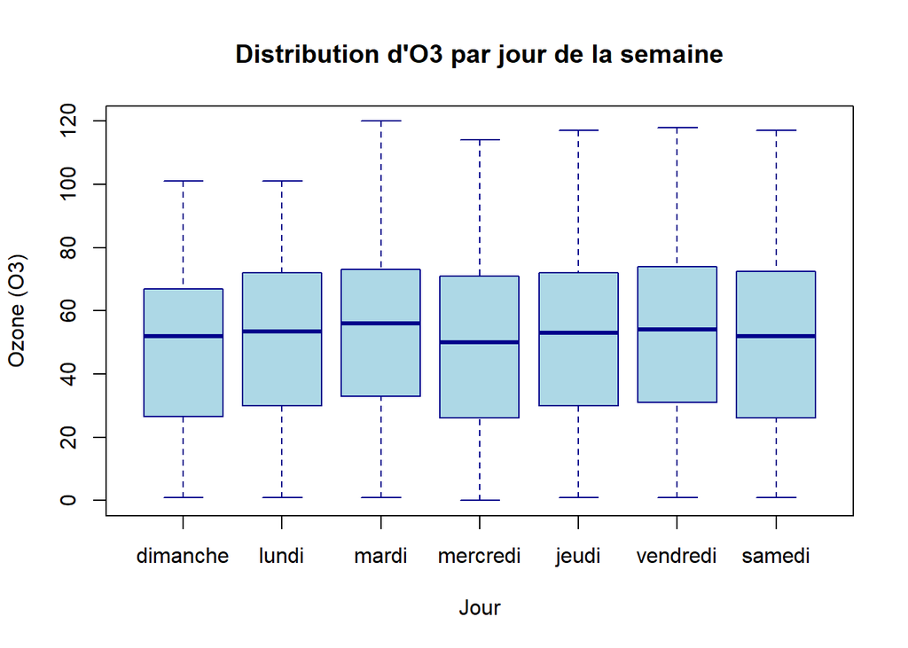

```r
boxplot(O3 ~ jour, data = df,
        xlab = "Jour", ylab = "Ozone (O3)",
        main = "Distribution d'O3 par jour de la semaine",
        col = "lightblue", border = "darkblue",
        outline = TRUE)
```

La médiane et les étendues interquartiles sont relativement stables d’un jour à l’autre, suggérant qu’il n’y a pas de variation significative dans les concentrations médianes d’ozone entre les jours. Les valeurs maximales et minimales varient légèrement entre les jours, mais globalement, elles restent dans des plages similaires, montrant une homogénéité des taux d’ozone.

Il semblerait que les concentrations d’ozone ne dépendent pas directement des jours de la semaine.

## 2.4 ACP complète et identification des individus extrêmes

Après avoir centré les variables, on réalise l’ACP.

```r
df_numeric_scaled <- scale(df_numeric)

acp_result <- prcomp(df_numeric_scaled, center = TRUE, scale. = TRUE)

#summary(acp_result)
```

Les premières composantes principales (PC1 et PC2) expliquent environ 40% de la variance totale, ce qui est assez faible. Une précision plus élevée est nécessaire, les 6 premières composantes expliqueraient environ 70% de la variance, et les 11 premières plus de 85%.

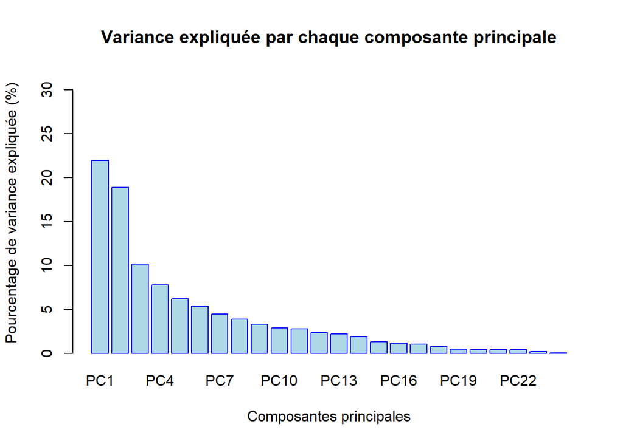

```r
variances <- summary(acp_result)$importance[2, ] * 100

barplot(variances,
        main = "Variance expliquée par chaque composante principale",
        col = "lightblue",
        ylim = c(0, max(variances) + 10),
        xlab = "Composantes principales",
        ylab = "Pourcentage de variance expliquée (%)",
        border = "blue")
```

D’après la méthode du coude, on observe que les deux premières composantes expliquent la majeure partie de la variance.

```r
#ecarts_types <- acp_result$sdev
#valeurs_propres <- ecarts_types^2
```

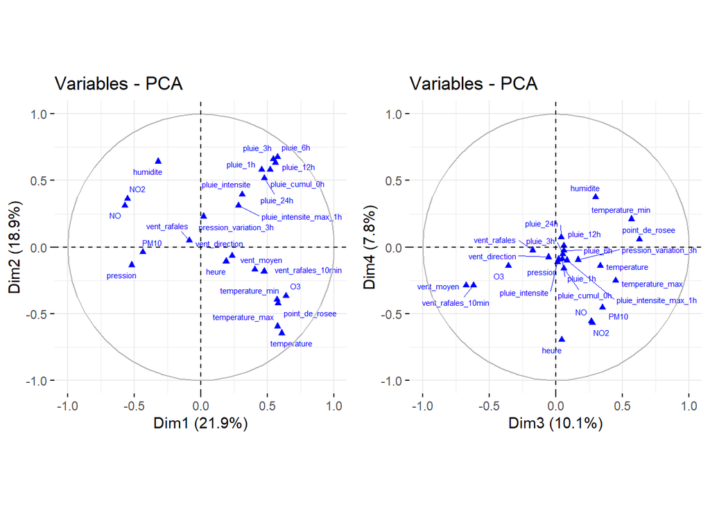

```r
graph1 <- fviz_mca_var(acp_result,
                       col.var = "blue",
                       label = "var",
                       repel = TRUE,
                       labelsize = 2)
graph2 <- fviz_mca_var(acp_result,
                       col.var = "blue",
                       label = "var",
                       repel = TRUE,
                       labelsize = 2,
                       axes = c(3, 4))
grid.arrange(graph1, graph2, ncol = 2)
```

En analysant les quatre dimensions principales, une vue plus complète des relations entre les variables émerge, chaque dimension apportant des éléments spécifiques :

**Dimension 1** : Les variables liées à la température (température, température_max) sont fortement corrélées positivement. Celles liées aux pluies et à l’ozone (O3) le sont modérément. À l’inverse, pression, NO, NO2 et PM10 montrent des corrélations négatives.

Sur les dimensions suivantes, les variables se situant majoritairement plus proches du centre du cercl,e sont moins bien projetées. Parmis les variables lisibles, en **Dimension 3** l’axe est dominé par la température, l’humidité et le vent. En **Dimension 4** l’axe est dominé par l’heure, l’humidité et quelques variables de pollution.

Les variables montrent des liens forts : celles liées à la température et à l’ozone sont opposées à l’humidité et aux précipitations, tandis que la pression et les vents structurent des axes complémentaires.

En se concentrant sur les deux premières dimensions :

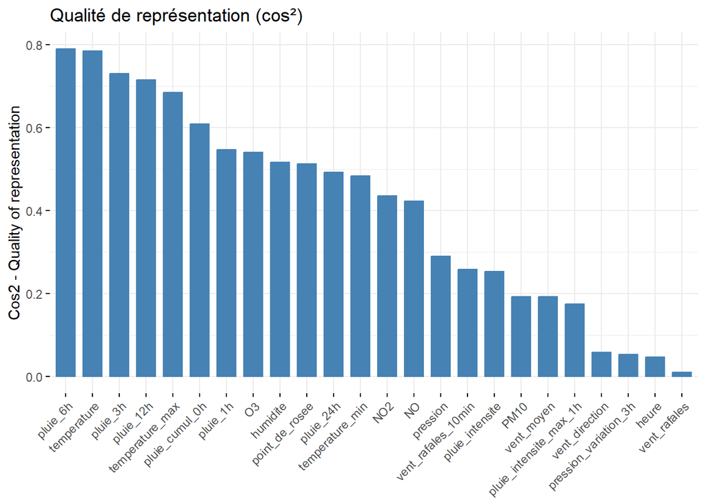

```r
fviz_cos2(acp_result, choice = "var", axes = 1:2, title = "Qualité de représentation (cos²)")
```

Les variables précipitations (pluie_6h, pluie_3h, pluie_12h) et les variables de température (temperature, temperature_max) sont bien représentées sur le plan factoriel, avec un cos² élevé. Cela reflète leur contribution importante à la structuration des composantes principales. En revanche, des variables comme vent_rafales, heure, ou pression_variation_3h ont des cos² faibles, confirmant leur mauvaise représentation dans le plan.

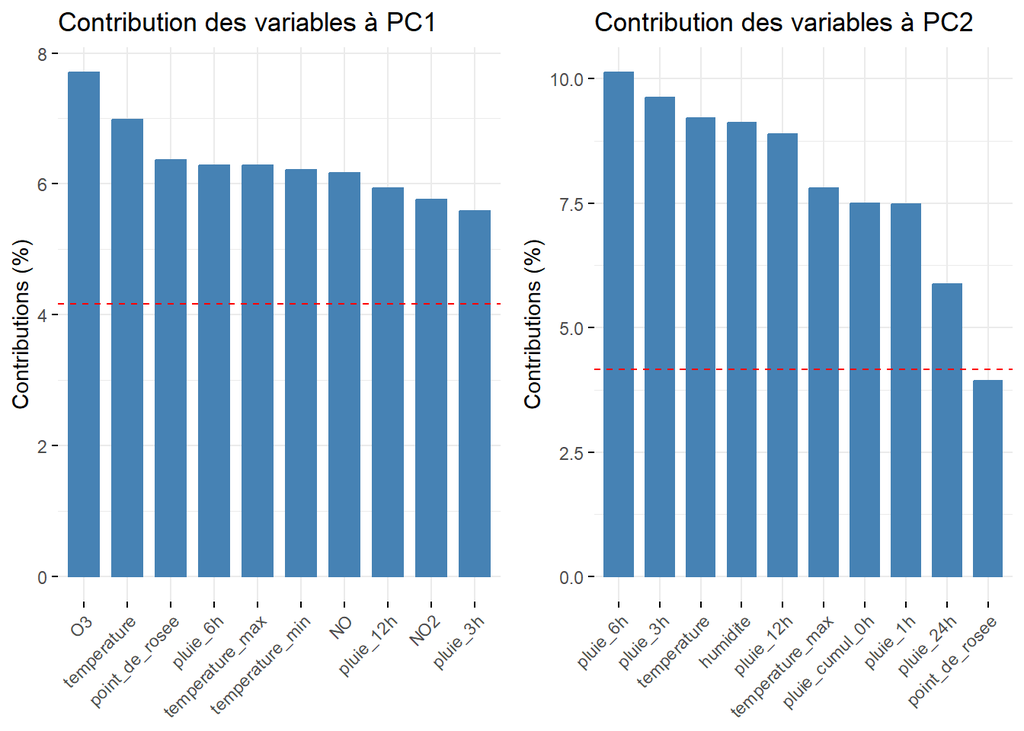

```r
p1 <- fviz_contrib(acp_result, choice = "var", axes = 1, top = 10, title = "Contribution des variables à PC1")
p2 <- fviz_contrib(acp_result, choice = "var", axes = 2, top = 10, title = "Contribution des variables à PC2")

grid.arrange(p1, p2, ncol = 2)
```

Les graphiques montrent les 10 variables qui contribuent le plus à la construction des deux axes principaux.

**PC1** : Les variables O3, temperature, et point_de_rosée contribuent le plus, confirmant leur position proche du cercle. Les précipitations (pluie_6h, pluie_12h) et les polluants (NO, NO2) ont une contribution moindre mais significative.

**PC2** : Les précipitations (pluie_6h, pluie_3h, pluie_12h) et temperature dominent cet axe.

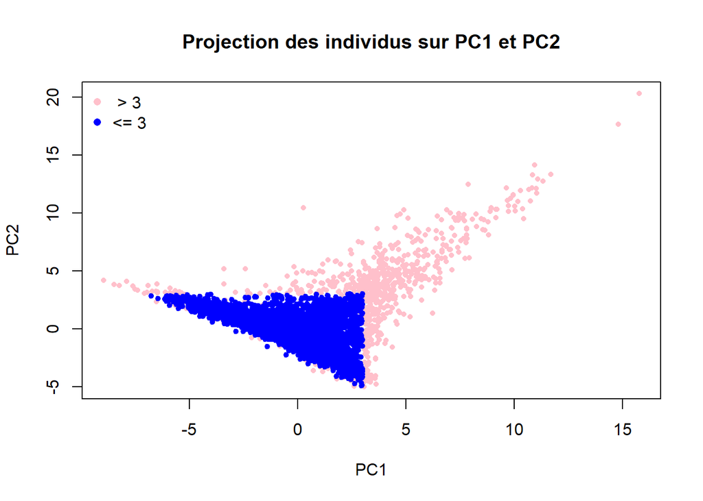

```r
coord_individus_all <- acp_result$x

individus_plus_3 <- coord_individus_all[apply(coord_individus_all, 1, function(x) all(x > 3)), ]

individus_moins_3 <- coord_individus_all[apply(coord_individus_all, 1, function(x) all(x <= 3)), ]


coord_individus_pc1_pc2 <- coord_individus_all[, 1:2]

plot(coord_individus_pc1_pc2, main = "Projection des individus sur PC1 et PC2",
     xlab = "PC1", ylab = "PC2", col = "pink", pch = 16, cex = 0.7)
points(individus_moins_3[, 1:2], col = "blue", pch = 19, cex = 0.7)
legend("topleft",
       legend = c(" > 3", "<= 3"),
       col = c("pink", "blue"),
       pch = 16,
       cex = 1,
       bty = "n")
```

Les variables ayant les plus fortes contributions aux axes PC1 et PC2 influencent la position de ces individus. Ces écarts reflètent des différences marquées dans leurs caractéristiques par rapport à la moyenne. En analysant les données brutes, ces individus présentent des valeurs élevées ou faibles sur certaines variables spécifiques, renforçant leur éloignement dans l’espace factoriel.

```r
indices_pc1_top10 <- order(-coord_individus_pc1_pc2[, 1])[1:10]
indices_pc2_top10 <- order(-coord_individus_pc1_pc2[, 2])[1:10]

individus_originaux_pc1_top10 <- df[indices_pc1_top10, ]
individus_originaux_pc2_top10 <- df[indices_pc2_top10, ]

kable(individus_originaux_pc1_top10,format = "html",caption = "Top 10 individus éloignés sur Dim.1") %>%
  kable_styling(bootstrap_options = c("striped","hover","condensed"),full_width = FALSE) %>%
  scroll_box(width = "100%",height = "300px")
```

Top 10 individus éloignés sur Dim.1

| jour | date | heure | NO2 | O3 | NO | PM10 | temperature | pression | pression_variation_3h | humidite | point_de_rosee | vent_moyen | vent_rafales | vent_rafales_10min | vent_direction | temperature_min | temperature_max | pluie_1h | pluie_3h | pluie_6h | pluie_12h | pluie_24h | pluie_cumul_0h | pluie_intensite | pluie_intensite_max_1h |
| --- | --- | --- | --- | --- | --- | --- | --- | --- | --- | --- | --- | --- | --- | --- | --- | --- | --- | --- | --- | --- | --- | --- | --- | --- | --- |
| vendredi | 2024-09-06 | 17 | 12 | 28 | 13.2 | 10 | 16.6 | 1006.1 | 1.3 | 94 | 15.6 | 0.0 | 0 | 3.2 | 303 | 11.8 | 20.3 | 11.6 | 18.8 | 19.0 | 19.2 | 19.2 | 19.2 | 20.0 | 66.6 |
| jeudi | 2024-10-17 | 14 | 14 | 43 | 15.5 | 7 | 13.7 | 1006.9 | -0.5 | 92 | 12.2 | 4.8 | 0 | 19.3 | 207 | 13.7 | 17.6 | 11.0 | 19.8 | 20.2 | 28.2 | 31.2 | 30.8 | 6.4 | 9.8 |
| jeudi | 2024-10-17 | 16 | 4 | 66 | 6.0 | 4 | 13.8 | 1009.1 | 1.3 | 93 | 12.8 | 0.0 | 0 | 4.8 | 317 | 13.3 | 17.6 | 2.6 | 14.6 | 23.8 | 30.4 | 34.6 | 34.4 | 4.6 | 4.2 |
| vendredi | 2024-03-29 | 19 | 5 | 87 | 4.9 | 3 | 8.8 | 993.3 | 0.2 | 93 | 7.8 | 4.8 | 0 | 16.1 | 101 | 8.8 | 12.9 | 4.4 | 7.6 | 18.0 | 22.6 | 30.8 | 30.6 | 12.2 | 8.6 |
| vendredi | 2024-03-29 | 22 | 3 | 92 | 2.3 | 2 | 7.6 | 994.8 | 1.5 | 92 | 6.7 | 1.6 | 0 | 6.4 | 340 | 7.6 | 12.9 | 3.4 | 8.8 | 16.4 | 30.6 | 39.6 | 39.4 | 6.2 | 6.2 |
| jeudi | 2024-10-17 | 15 | 6 | 57 | 8.0 | 4 | 13.7 | 1007.3 | -0.4 | 93 | 12.8 | 3.2 | 0 | 12.9 | 281 | 13.3 | 17.6 | 1.0 | 18.4 | 21.2 | 27.8 | 32.2 | 31.8 | 0.0 | 9.8 |
| jeudi | 2024-10-17 | 17 | 8 | 55 | 9.7 | 4 | 13.5 | 1008.8 | 1.9 | 93 | 12.2 | 3.2 | 0 | 12.9 | 308 | 13.3 | 17.6 | 3.2 | 6.8 | 26.6 | 32.0 | 37.6 | 37.6 | 1.6 | 1.6 |
| vendredi | 2024-10-25 | 19 | 8 | 44 | 7.5 | 7 | 13.1 | 1014.8 | 0.6 | 94 | 12.2 | 0.0 | 0 | 3.2 | 259 | 13.1 | 16.9 | 11.0 | 14.2 | 15.4 | 16.0 | 16.4 | 16.4 | 7.2 | 18.2 |
| vendredi | 2024-09-06 | 18 | 11 | 27 | 11.5 | 8 | 16.6 | 1006.1 | 0.9 | 94 | 15.6 | 0.0 | 0 | 3.2 | 303 | 11.8 | 20.3 | 3.2 | 22.0 | 22.0 | 22.4 | 22.4 | 22.4 | 0.0 | 30.4 |
| vendredi | 2024-03-29 | 23 | 2 | 96 | 2.0 | 2 | 6.9 | 994.8 | 0.6 | 92 | 5.6 | 3.2 | 0 | 8.0 | 296 | 6.9 | 12.9 | 2.6 | 8.4 | 18.4 | 33.0 | 42.0 | 42.0 | 0.0 | 13.6 |

```r
kable(individus_originaux_pc2_top10,format = "html",caption = "Top 10 individus éloignés sur Dim.2") %>%
  kable_styling(bootstrap_options = c("striped","hover","condensed"),full_width = FALSE) %>%
  scroll_box(width = "100%",height = "300px")
```

Top 10 individus éloignés sur Dim.2

| jour | date | heure | NO2 | O3 | NO | PM10 | temperature | pression | pression_variation_3h | humidite | point_de_rosee | vent_moyen | vent_rafales | vent_rafales_10min | vent_direction | temperature_min | temperature_max | pluie_1h | pluie_3h | pluie_6h | pluie_12h | pluie_24h | pluie_cumul_0h | pluie_intensite | pluie_intensite_max_1h |
| --- | --- | --- | --- | --- | --- | --- | --- | --- | --- | --- | --- | --- | --- | --- | --- | --- | --- | --- | --- | --- | --- | --- | --- | --- | --- |
| vendredi | 2024-09-06 | 17 | 12 | 28 | 13.2 | 10 | 16.6 | 1006.1 | 1.3 | 94 | 15.6 | 0.0 | 0 | 3.2 | 303 | 11.8 | 20.3 | 11.6 | 18.8 | 19.0 | 19.2 | 19.2 | 19.2 | 20.0 | 66.6 |
| jeudi | 2024-10-17 | 14 | 14 | 43 | 15.5 | 7 | 13.7 | 1006.9 | -0.5 | 92 | 12.2 | 4.8 | 0 | 19.3 | 207 | 13.7 | 17.6 | 11.0 | 19.8 | 20.2 | 28.2 | 31.2 | 30.8 | 6.4 | 9.8 |
| vendredi | 2024-10-25 | 19 | 8 | 44 | 7.5 | 7 | 13.1 | 1014.8 | 0.6 | 94 | 12.2 | 0.0 | 0 | 3.2 | 259 | 13.1 | 16.9 | 11.0 | 14.2 | 15.4 | 16.0 | 16.4 | 16.4 | 7.2 | 18.2 |
| jeudi | 2024-10-17 | 16 | 4 | 66 | 6.0 | 4 | 13.8 | 1009.1 | 1.3 | 93 | 12.8 | 0.0 | 0 | 4.8 | 317 | 13.3 | 17.6 | 2.6 | 14.6 | 23.8 | 30.4 | 34.6 | 34.4 | 4.6 | 4.2 |
| vendredi | 2024-09-06 | 18 | 11 | 27 | 11.5 | 8 | 16.6 | 1006.1 | 0.9 | 94 | 15.6 | 0.0 | 0 | 3.2 | 303 | 11.8 | 20.3 | 3.2 | 22.0 | 22.0 | 22.4 | 22.4 | 22.4 | 0.0 | 30.4 |
| vendredi | 2024-03-29 | 22 | 3 | 92 | 2.3 | 2 | 7.6 | 994.8 | 1.5 | 92 | 6.7 | 1.6 | 0 | 6.4 | 340 | 7.6 | 12.9 | 3.4 | 8.8 | 16.4 | 30.6 | 39.6 | 39.4 | 6.2 | 6.2 |
| vendredi | 2024-03-29 | 19 | 5 | 87 | 4.9 | 3 | 8.8 | 993.3 | 0.2 | 93 | 7.8 | 4.8 | 0 | 16.1 | 101 | 8.8 | 12.9 | 4.4 | 7.6 | 18.0 | 22.6 | 30.8 | 30.6 | 12.2 | 8.6 |
| lundi | 2024-02-12 | 11 | 13 | 43 | 15.9 | 6 | 7.3 | 1003.5 | 1.2 | 95 | 6.7 | 4.8 | 0 | 11.3 | 116 | 4.2 | 7.3 | 7.6 | 12.6 | 14.4 | 14.4 | 16.0 | 14.4 | 5.4 | 5.4 |
| vendredi | 2024-10-25 | 20 | 7 | 49 | 7.8 | 7 | 12.9 | 1014.7 | 0.6 | 95 | 12.2 | 0.0 | 0 | 3.2 | 232 | 12.9 | 16.9 | 3.2 | 14.6 | 18.6 | 19.0 | 19.6 | 19.6 | 9.8 | 16.2 |
| vendredi | 2024-03-29 | 23 | 2 | 96 | 2.0 | 2 | 6.9 | 994.8 | 0.6 | 92 | 5.6 | 3.2 | 0 | 8.0 | 296 | 6.9 | 12.9 | 2.6 | 8.4 | 18.4 | 33.0 | 42.0 | 42.0 | 0.0 | 13.6 |

Les individus présentant les plus grandes coordonnées (en abscisses et en ordonnées) correspondent principalement à des dates situées majoritairement aux mois :

Ces périodes traduisent des contextes climatiques spécifiques qui favorisent des anomalies dans les niveaux d’ozone et d’autres variables météorologiques.

## 2.6 ACP simplifiée avec des représentants de chaque groupe

La variable pluie_6h, étant la mieux projetée, on l’a conservée parmi les variables de précipitation. Cette simplification vise à réduire la redondance tout en conservant l’information la plus pertinente pour l’analyse.

On réitère l’ACP.

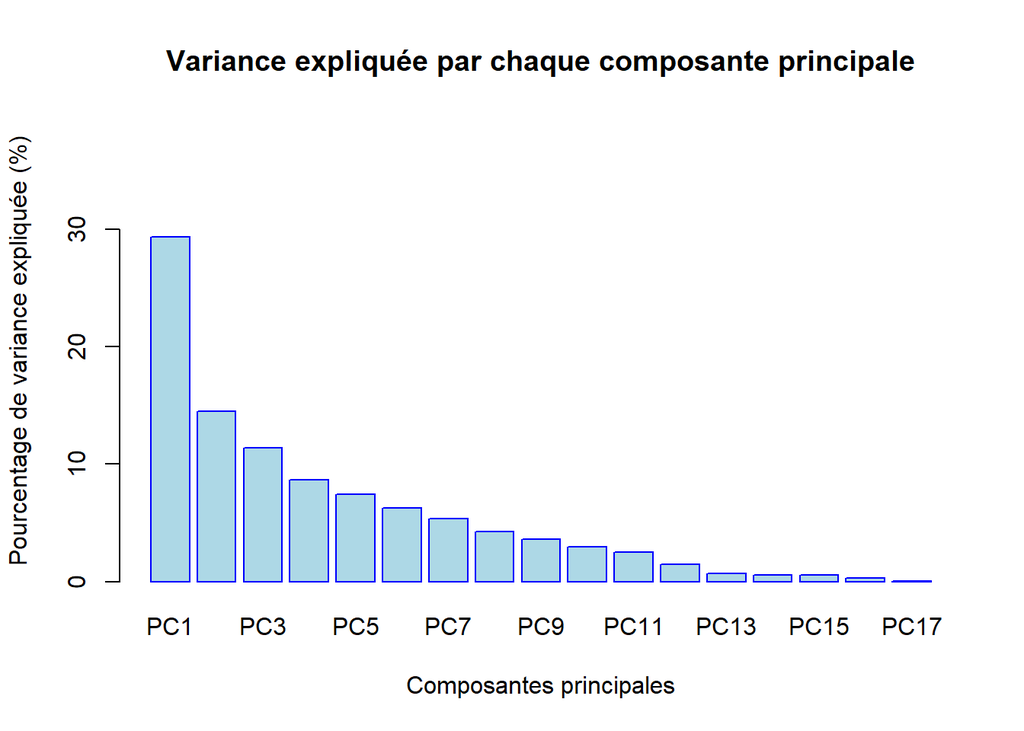

```r
df_numeric <- df %>% select_if(is.numeric)

df2 <- df_numeric %>% select(-c(pluie_1h, pluie_3h, pluie_12h, pluie_24h, pluie_cumul_0h, pluie_intensite, pluie_intensite_max_1h))

df_numeric_scaled2 <- scale(df2)

acp_result <- prcomp(df_numeric_scaled2, center = TRUE, scale. = TRUE)

variances <- summary(acp_result)$importance[2, ] * 100
#summary(acp_result)

barplot(variances,
        main = "Variance expliquée par chaque composante principale",
        col = "lightblue",
        ylim = c(0, max(variances) + 10),
        xlab = "Composantes principales",
        ylab = "Pourcentage de variance expliquée (%)",
        border = "blue")
```

Les deux premières composantes principales (PC1 et PC2) expliquent 43,85% de la variance totale, ce qui reste relativement faible pour une analyse en deux dimensions. En comparaison avec la première ACP, où PC1 et PC2 expliquaient près de 40,8% de la variance, cette configuration apporte une légère amélioration en termes de capacité explicative initiale.

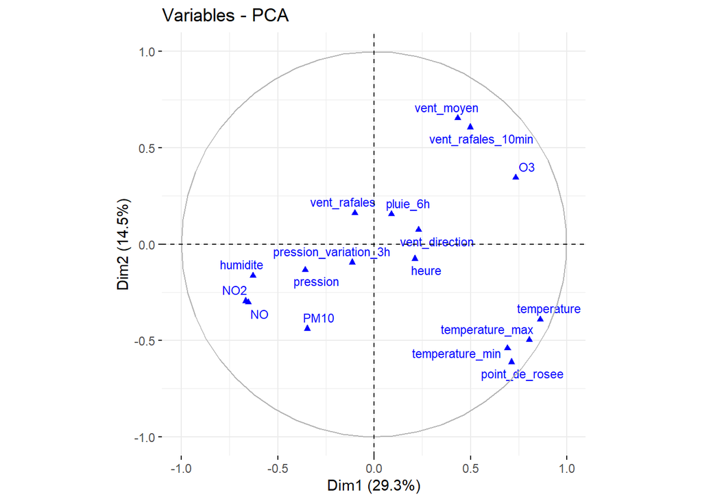

```r
fviz_mca_var(acp_result,
             col.var = "blue",
             label = "var",
             repel = TRUE,
             labelsize = 3)
```

**Dimension 1** : Les variables liées à la température (température, température_max, température_min, et point_de_rosée) sont fortement corrélées positivement, tout comme dans la première ACP. Les variables liées à la pollution (NO, NO2) et à l’humidité montrent à nouveau une corrélation négative significative, confirmant leur rôle opposé sur cet axe.

**Dimension 2** : Cet axe est dominé par les variables liées au vent (vent_moyen et vent_rafales_10min), illustrant une différence notable par rapport à la première ACP où les précipitations dominaient PC2. Cette distinction souligne une nouvelle dimension liée aux conditions atmosphériques plutôt qu’aux précipitations.

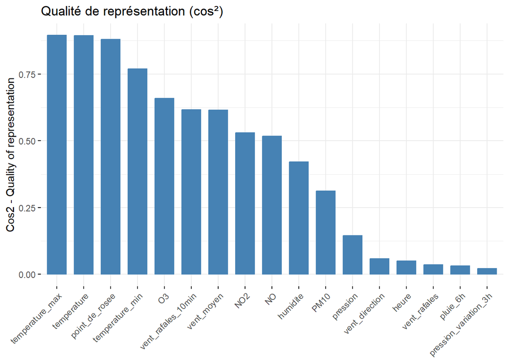

```r
fviz_cos2(acp_result, choice = "var", axes = 1:2, title = "Qualité de représentation (cos²)")
```

Les variables de température (température_max, température, et point_de_rosée) restent les mieux représentées, avec des cos² proches de 0.8, tout comme dans la première ACP. Cependant, pluie_6h possède un cos² faible (< 0,1), démontrant mant une faible influence sur la structuration des axes principaux.

Comparée à la première ACP, où les variables de précipitations avaient une influence plus marquée, cette nouvelle configuration montre une réduction de leur rôle au profit des variables de vent et de température.

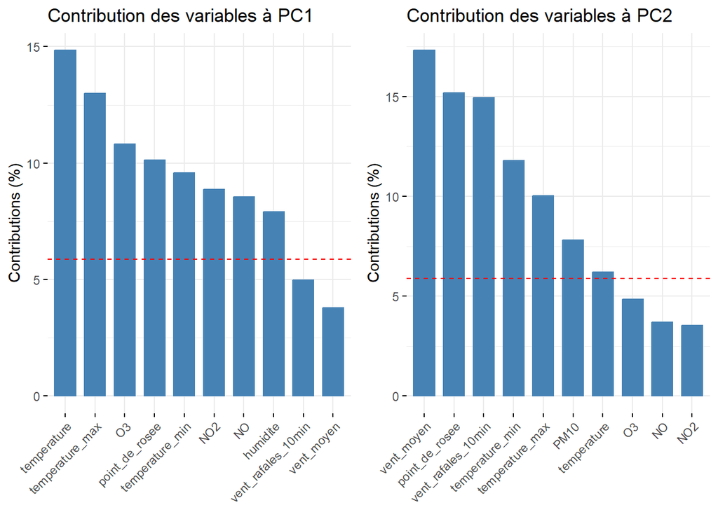

```r
p1 <- fviz_contrib(acp_result, choice = "var", axes = 1, top = 10, title = "Contribution des variables à PC1")
p2 <- fviz_contrib(acp_result, choice = "var", axes = 2, top = 10, title = "Contribution des variables à PC2")

grid.arrange(p1, p2, ncol = 2)
```

**PC1** : Les variables température, température_max, et O3 continuent de dominer avec des contributions supérieures à 10%. Cette cohérence avec la première ACP confirme que PC1 est principalement structuré par des conditions thermiques et chimiques.

**PC2** : Les variables vent_moyen et vent_rafales_10min prennent une place dominante, avec des contributions proches de 15%, illustrant un déplacement significatif par rapport à la première ACP, où cet axe était largement influencé par les précipitations.

La conservation d’une seule variable de précipitation a permis de mieux représenter les dimensions liées aux conditions de vent dans PC2. Cette révision de l’analyse montre que les conditions de vent jouent un rôle plus important lorsque les précipitations sont simplifiées. Par conséquent, cette deuxième ACP met davantage l’accent sur les influences atmosphériques (vent) et thermiques (température), tout en réduisant l’impact des variables de précipitation.

## 2.6 ACP simplifiée avec des représentants de chaque groupe

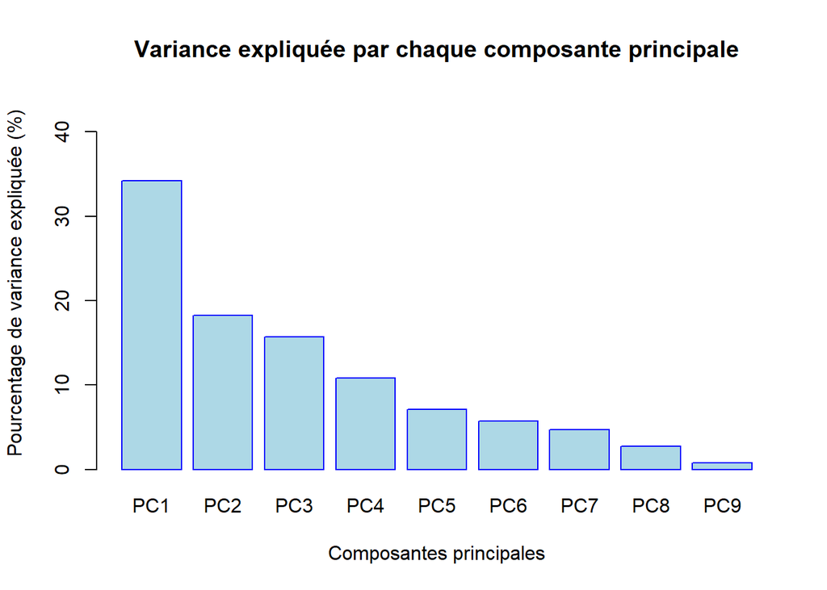

```r
df3 <- df %>% select(c(pluie_6h, vent_moyen, temperature_max, humidite, NO, O3, PM10, pression, point_de_rosee))

df_numeric_scaled3 <- scale(df3)

acp_result <- prcomp(df_numeric_scaled3, center = TRUE, scale. = TRUE)

df3_sup <- df_numeric %>% select(c(pluie_6h, vent_moyen, temperature_max, humidite, NO, O3, PM10, pression, point_de_rosee))

df3_sup_scaled <- scale(df3_sup)

sup_proj <- predict(acp_result, newdata = df3_sup_scaled)

variances <- summary(acp_result)$importance[2, ] * 100

barplot(variances,
        main = "Variance expliquée par chaque composante principale",
        col = "lightblue",
        ylim = c(0, max(variances) + 10),
        xlab = "Composantes principales",
        ylab = "Pourcentage de variance expliquée (%)",
        border = "blue")
```

Les deux premières composantes principales expliquent environ 52.4% de la variance totale, ce qui constitue une nette amélioration par rapport aux deux premières ACP (41% sur les deux axes principaux et 43%). Cela reflète une meilleure représentation globale des variables principales. Avec les cinq premières composantes, la couverture atteint près de 85% de la variance totale, démontrant une structuration plus efficace.

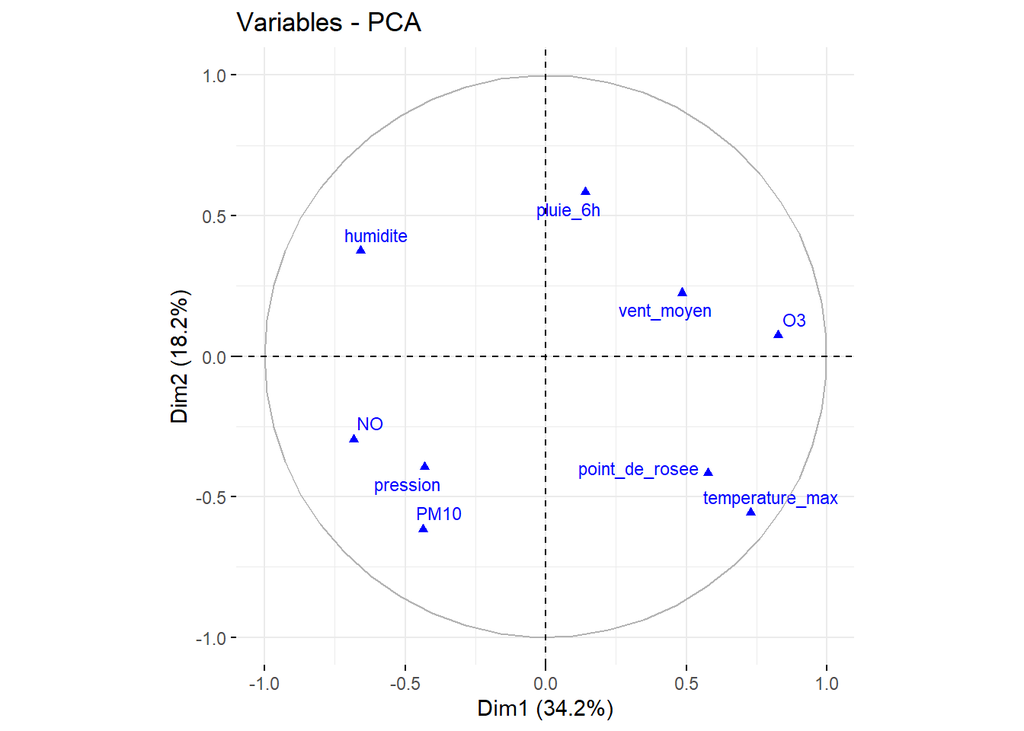

```r
fviz_mca_var(acp_result,
             col.var = "blue",
             label = "var",
             repel = TRUE,
             labelsize = 3)
```

**Dimension 1** : Cet axe oppose les variables thermiques et chimiques (temperature_max, O3) aux variables liées aux particules fines et à la pression (PM10, pression). Cette structure est cohérente avec les résultats des deux premières ACP, où PC1 était également dominé par des variables thermiques.

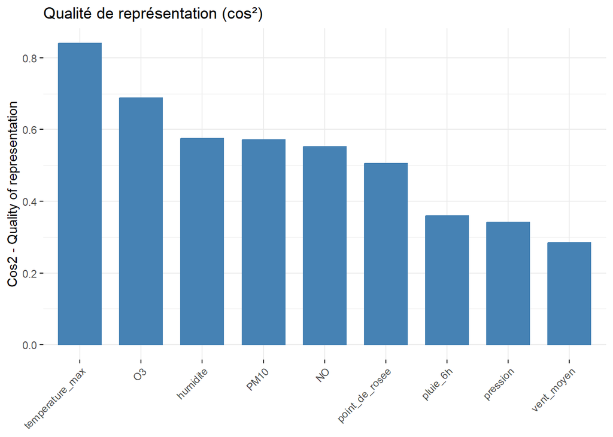

```r
fviz_cos2(acp_result, choice = "var", axes = 1:2, title = "Qualité de représentation (cos²)")
```

Les variables temperature_max, O3, et humidite affichent les meilleures qualités de représentation, confirmant leur importance dans la structuration du plan factoriel. Cette observation est cohérente avec les deux premières ACP, où ces variables figuraient déjà parmi les mieux représentées. En revanche, vent_moyen et pression, bien que pertinentes, ont une représentation légèrement inférieure.

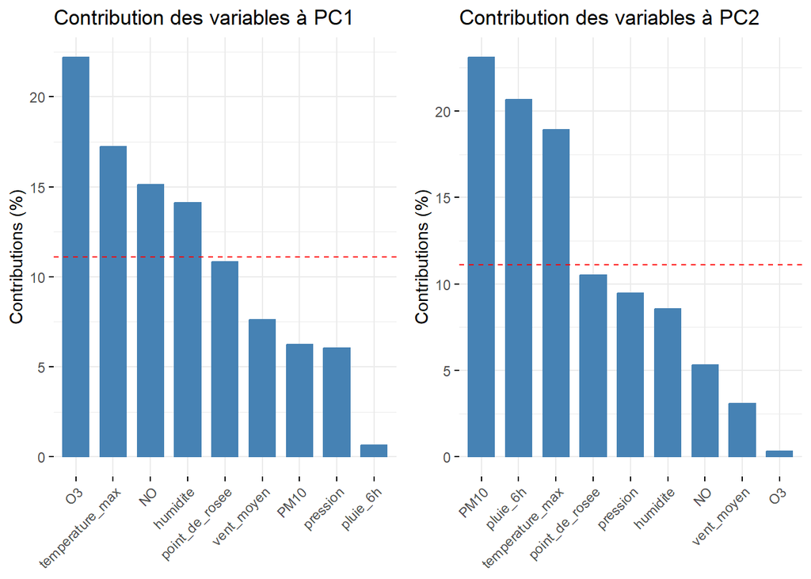

```r
p1 <- fviz_contrib(acp_result, choice = "var", axes = 1, top = 10, title = "Contribution des variables à PC1")
p2 <- fviz_contrib(acp_result, choice = "var", axes = 2, top = 10, title = "Contribution des variables à PC2")

grid.arrange(p1, p2, ncol = 2)
```

**PC1** : Les variable O3 domine avec une contribution dépassant 20%, confirmant son rôle structurant sur cet axe.

**PC2** : L’axe est dominé par PM10 et pluie_6h, avec des contributions excédant 20%.

Cette troisième ACP se distingue par une répartition plus homogène des contributions entre les variables, grâce à la simplification opérée dans la sélection des variables principales. Comparée à la première ACP, où les précipitations étaient mieux représentées, et à la deuxième ACP, où les vents étaient dominants sur PC2, cette analyse met en avant un équilibre entre conditions thermiques, chimiques et pluvieuses.

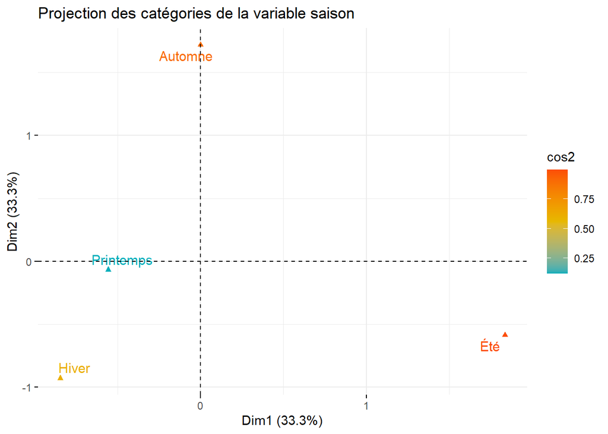

```r
df <- df %>%
  mutate(
    saison = case_when(
      format(date, "%m") %in% c("12", "01", "02") ~ "Hiver",
      format(date, "%m") %in% c("03", "04", "05") ~ "Printemps",
      format(date, "%m") %in% c("06", "07", "08") ~ "Été",
      format(date, "%m") %in% c("09", "10", "11") ~ "Automne",
      TRUE ~ NA_character_
    )
  )

df_acm <- df %>%
  select(saison) %>%
  mutate(saison = as.factor(saison))

resultat_acm <- MCA(df_acm, graph = TRUE)


fviz_mca_var(
  resultat_acm,
  col.var = "cos2",
  gradient.cols = c("#00AFBB", "#E7B800", "#FC4E07"),
  repel = TRUE
) +
  labs(title = "Projection des catégories de la variable saison")
```

# 3 Problématique et méthode multivariée

```r
 #require(Factoshiny)
 #res <- Factoshiny(df[,-c(1,2)])
```

**Problématique : Quels sont les facteurs météorologiques et les conditions environnementales qui influencent la concentration d’O3, et comment évolue-t-elle au cours de l’année 2024 à Périgueux ?**

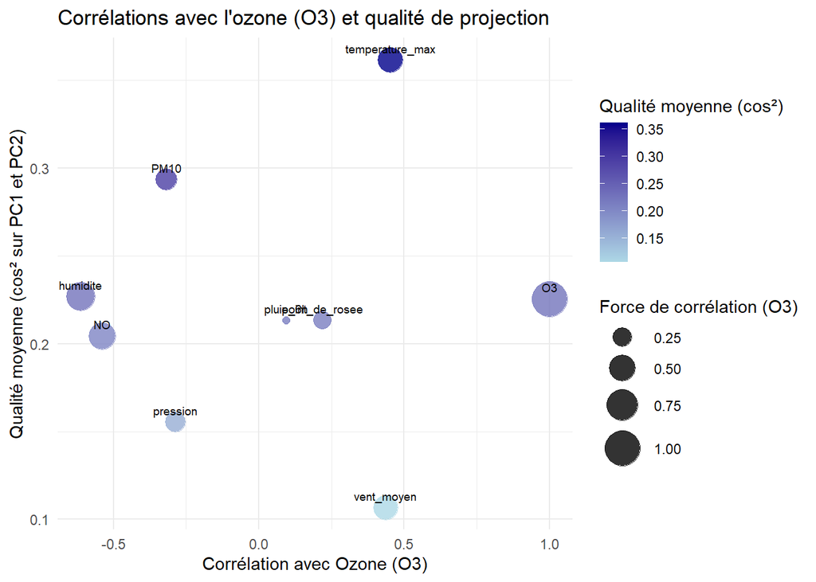

```r
correlation_with_ozone <- cor(df3, use = "complete.obs")[, "O3"] %>% as.data.frame()
colnames(correlation_with_ozone) <- "correlation_with_ozone"
correlation_with_ozone <- tibble::rownames_to_column(correlation_with_ozone, var = "variable")

cos2 <- as.data.frame(acp_result$rotation^2) %>%
  rownames_to_column(var = "variable") %>%
  mutate(cos2_PC1_PC2 = PC1 + PC2)

scatter_data <- correlation_with_ozone %>%
  left_join(cos2 %>% select(variable, cos2_PC1_PC2), by = "variable")

ggplot(scatter_data, aes(x = correlation_with_ozone, y = cos2_PC1_PC2)) +
  geom_point(aes(size = abs(correlation_with_ozone), color = cos2_PC1_PC2), alpha = 0.8) +
  geom_text(aes(label = variable), vjust = -0.8, hjust = 0.5, size = 2.5) +
  scale_size(range = c(2, 10), name = "Force de corrélation (O3)") +
  scale_color_gradient(low = "lightblue", high = "darkblue", name = "Qualité moyenne (cos²)") +
  labs(
    title = "Corrélations avec l'ozone (O3) et qualité de projection",
    x = "Corrélation avec Ozone (O3)",
    y = "Qualité moyenne (cos² sur PC1 et PC2)"
  ) +
  theme_minimal() +
  theme(legend.position = "right")
```

Une régression linéaire a été réalisée pour évaluer quantitativement l’impact des différentes variables sur O3.

```r
lm_model <- lm(O3 ~ ., data = df3)

lm_summary <- tidy(lm_model)

kable(
  lm_summary,
  caption = "Résumé du modèle linéaire pour Ozone (O3)",
  digits = 3,
  align = 'c'
)
```

Résumé du modèle linéaire pour Ozone (O3)

| term | estimate | std.error | statistic | p.value |
| --- | --- | --- | --- | --- |
| (Intercept) | 459.804 | 23.316 | 19.720 | 0 |
| pluie_6h | 1.198 | 0.087 | 13.794 | 0 |
| vent_moyen | 2.155 | 0.117 | 18.388 | 0 |
| temperature_max | 1.560 | 0.071 | 22.122 | 0 |
| humidite | -0.553 | 0.022 | -24.831 | 0 |
| NO | -0.781 | 0.020 | -38.313 | 0 |
| PM10 | -0.185 | 0.031 | -5.879 | 0 |
| pression | -0.362 | 0.023 | -15.902 | 0 |
| point_de_rosee | -1.565 | 0.082 | -19.040 | 0 |

La régression linéaire montre que l’ozone (O3) est positivement influencé par des variables telles que pluie_6h, vent_moyen, et temperature_max, tandis qu’il est négativement impacté par l’humidité, la concentration de NO, les particules PM10, la pression et le point de rosée, avec tous les coefficients étant statistiquement significatifs au seuil de 5%.

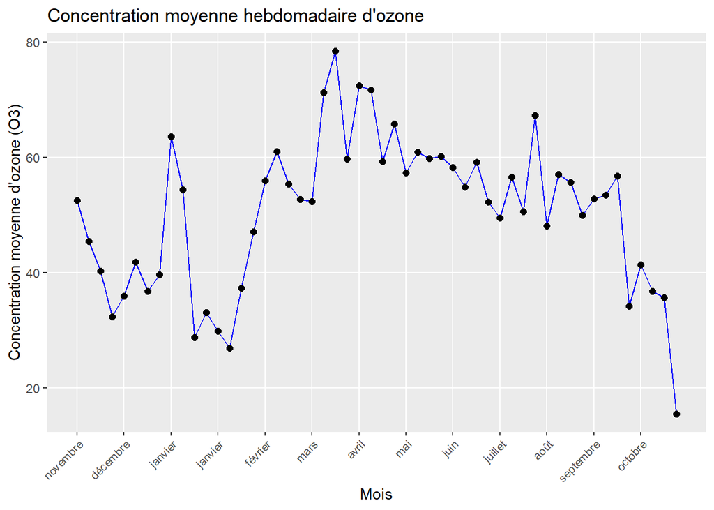

```r
df <- df %>%
  mutate(week = format(date, "%Y-%U"))

df_weekly <- df %>%
  group_by(week) %>%
  summarise(mean_ozone = mean(O3, na.rm = TRUE)) %>%
  mutate(week_index = row_number())

df_weekly <- df_weekly %>%
  mutate(
    month_label = case_when(
      week_index %% 4 == 1 ~ format(as.Date(paste0(substr(week, 1, 4), "-01-01")) + (as.numeric(substr(week, 6, 7)) * 7), "%B"),
      TRUE ~ NA_character_
    )
  )

ggplot(df_weekly, aes(x = week_index, y = mean_ozone)) +
  geom_line(color = "blue", group = 1) +
  geom_point(color = "black", size = 2) +
  scale_x_continuous(
    breaks = df_weekly$week_index[!is.na(df_weekly$month_label)],
    labels = df_weekly$month_label[!is.na(df_weekly$month_label)]
  ) +
  labs(
    title = "Concentration moyenne hebdomadaire d'ozone",
    x = "Mois",
    y = "Concentration moyenne d'ozone (O3)"
  ) +
  theme(
    axis.text.x = element_text(angle = 45, hjust = 1, size = 8),
    panel.grid.minor = element_blank()
  )
```

Le graphique des concentrations hebdomadaires moyennes d’ozone montre des fluctuations significatives au cours de l’année 2024.

Automne et hiver : Les concentrations d’ozone diminuent à mesure que les températures baissent et que les précipitations augmentent, réduisant ainsi les conditions favorables à sa formation.

Des variations marquées ont également été observées en octobre, avec des fluctuations importantes liées à des conditions météorologiques spécifiques probablement des tempêtes ou épisodes de vent fort.